# Taller 1 (corregido) - Análisis exploratorio de las 33 variables educativas municipales

Estadística Multidimensional

2026-10-31

## 0. Qué se corrigió respecto a la versión anterior

Este documento reemplaza el análisis exploratorio previo y analiza las **33 variables** de **`data/raw/educacion_limpio.csv`**: **30 indicadores numéricos** (resumen, histogramas, boxplots, correlaciones) y **3 variables categóricas** —`AÑO`, `DEPARTAMENTO` y `MUNICIPIO`— (frecuencias y cuánta varianza de cada indicador explica cada una).

| Problema en la versión anterior | Corrección aplicada |
| --- | --- |
| El código hacía `as.factor(CÓDIGO_MUNICIPIO)`, columna que **no existe** en el archivo limpio: el informe fallaba. Una solución intermedia leía el dataset de los talleres (5.063 registros, sin año ni … | El informe lee `educacion_limpio.csv` (13.802 registros, 33 variables). El municipio se identifica con `MUNICIPIO` + `DEPARTAMENTO`. |
| Las categóricas no se analizaban; `AÑO` podía entrar como número en histogramas, correlaciones y covarianzas. | `AÑO` es una categoría ordenada y las tres categóricas se analizan por separado. Los indicadores son las 30 columnas numéricas (`columnas_indicadores()` falla si `AÑO` se cuela). |
| Se trataban las 13.802 filas como si fueran municipios distintos. | Se documenta el panel (1.123 municipios, hasta 14 años cada uno) y la incertidumbre de las correlaciones se mide con **bootstrap por municipio**. |
| Pruebas de significancia sin ajuste. | No se reportan valores p: se reporta la magnitud de `r` con su intervalo por conglomerados y su sensibilidad. |
| Boxplots con normalización Min-Max, que no añade información (los boxplots ya son invariantes a transformaciones lineales). | Boxplots en la escala original, un panel por indicador, con conteo de atípicos por regla IQR. |
| Conclusiones con adjetivos no validados («crisis educativas severas», «correlación perfecta», sesgos con el signo invertido). | Conclusiones reescritas con cifras calculadas en este documento. |

## 1. Datos y estructura de panel

```r
datos <- cargar_educacion(project_root)
indicadores <- columnas_indicadores(datos)
X <- datos[, indicadores]
panel <- resumen_panel(datos)

stopifnot(!"AÑO" %in% indicadores, !anyNA(X),
          !any(duplicated(datos[, c("AÑO", "ID_MUNICIPIO")])))
columnas_constantes <- indicadores[vapply(X, function(x) length(unique(x)) <= 1, logical(1))]
```

El archivo tiene **13.802 registros** y 33 columnas originales. Cada fila es un **municipio-año**: corresponden a **1.123 municipios** distintos en **33 departamentos** y 14 años (2011-2024). Solo 404 municipios aparecen los 14 años; el municipio típico (mediana) aparece 13 años. No hay valores faltantes ni filas duplicadas por municipio-año, y ninguna columna es constante.

```r
por_anio <- panel$por_anio
por_anio$AÑO <- as.integer(as.character(por_anio$AÑO))
por_anio$referencia_2016_2024 <- round(median(por_anio$registros[por_anio$AÑO >= 2016]))
por_anio$faltan_vs_referencia <- por_anio$referencia_2016_2024 - por_anio$registros
write.csv(por_anio, file.path(tables_dir, "Panel_registros_por_anio.csv"), row.names = FALSE)
kable(por_anio, caption = "Registros por año frente a la referencia 2016-2024.")
```

Registros por año frente a la referencia 2016-2024.

| AÑO | registros | referencia_2016_2024 | faltan_vs_referencia |
| --- | --- | --- | --- |
| 2011 | 711 | 1116 | 405 |
| 2012 | 813 | 1116 | 303 |
| 2013 | 796 | 1116 | 320 |
| 2014 | 752 | 1116 | 364 |
| 2015 | 673 | 1116 | 443 |
| 2016 | 1114 | 1116 | 2 |
| 2017 | 1114 | 1116 | 2 |
| 2018 | 1115 | 1116 | 1 |
| 2019 | 1116 | 1116 | 0 |
| 2020 | 1113 | 1116 | 3 |
| 2021 | 1121 | 1116 | -5 |
| 2022 | 1121 | 1116 | -5 |
| 2023 | 1121 | 1116 | -5 |
| 2024 | 1122 | 1116 | -6 |

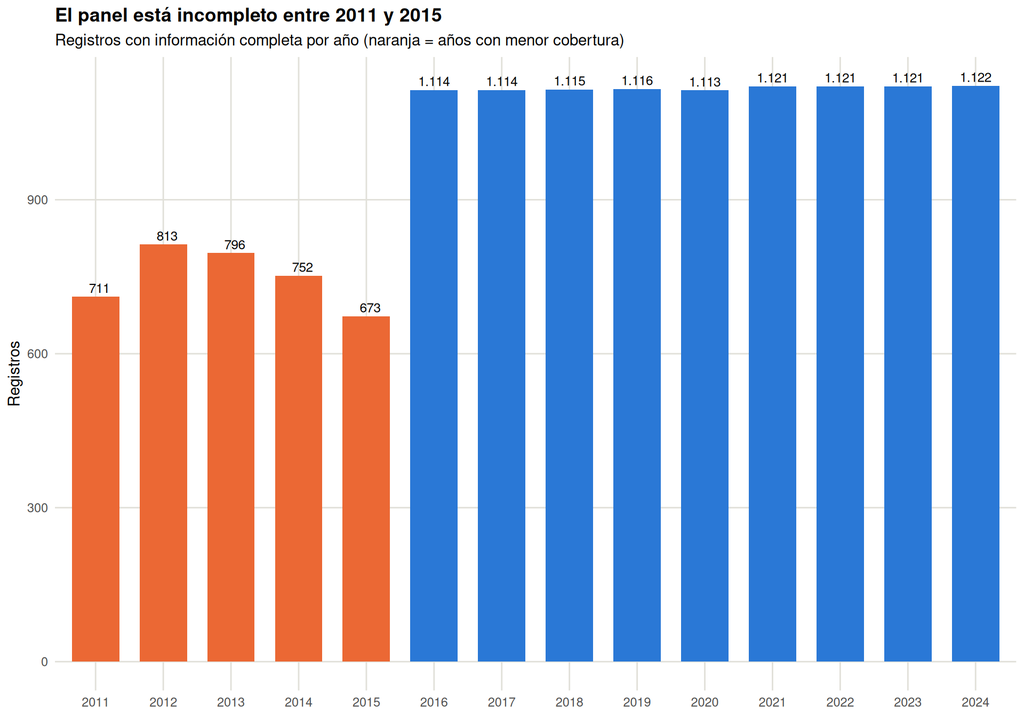

```r
p_panel <- ggplot(por_anio, aes(factor(AÑO), registros)) +
  geom_col(fill = ifelse(por_anio$AÑO < 2016, paleta$naranja, paleta$azul), width = 0.7) +
  geom_text(aes(label = fint(registros)), vjust = -0.4, size = 3.2) +
  tema + labs(title = "El panel está incompleto entre 2011 y 2015",
              subtitle = "Registros con información completa por año (naranja = años con menor cobertura)",
              x = NULL, y = "Registros")
print(p_panel)
```

```r
ggsave(file.path(figures_dir, "Registros_por_anio.png"), p_panel, width = 10, height = 5, dpi = 150)
```

**Lectura.** Entre 2011 y 2015 hay entre 673 y 813 registros por año; desde 2016 hay alrededor de 1.116. Los años iniciales están sub-representados, así que cualquier promedio global pesa más a 2016-2024. El archivo limpio no permite saber *qué* municipios faltan en esos años, por lo que **no se puede descartar un sesgo de selección**; por eso las asociaciones clave se recalculan solo con 2016-2024 (sección 6).

### Las tres variables categóricas

Las 33 columnas son 30 indicadores y 3 categóricas. Se describen sus categorías y se mide **cuánta varianza de cada indicador explica cada una** con el R² ajustado por número de categorías (`eta2_ajustado()`; un valor alto indica que los registros de una misma categoría se parecen entre sí).

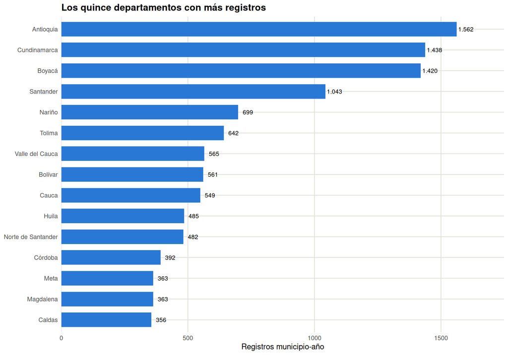

```r
n_dep <- length(unique(datos$DEPARTAMENTO))
por_dep <- datos %>% count(DEPARTAMENTO, name = "registros", sort = TRUE) %>%
  left_join(datos %>% distinct(DEPARTAMENTO, ID_MUNICIPIO) %>% count(DEPARTAMENTO, name = "municipios"), by = "DEPARTAMENTO")
write.csv(por_dep, file.path(tables_dir, "Categoricas_registros_por_departamento.csv"), row.names = FALSE)

p_dep <- ggplot(head(por_dep, 15), aes(reorder(DEPARTAMENTO, registros), registros)) +
  geom_col(fill = paleta$azul, width = 0.7) + coord_flip() +
  geom_text(aes(label = fint(registros)), hjust = -0.1, size = 3) +
  scale_y_continuous(expand = expansion(mult = c(0, 0.12))) +
  tema + labs(title = "Los quince departamentos con más registros", x = NULL, y = "Registros municipio-año")
print(p_dep)
```

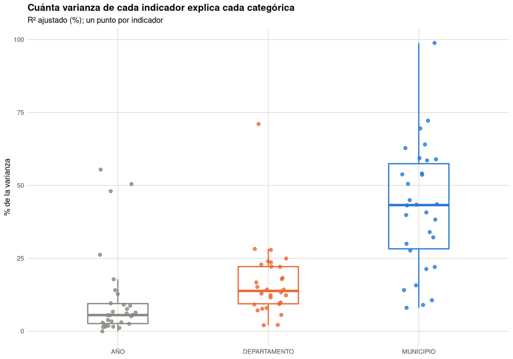

```r
ggsave(file.path(figures_dir, "Registros_por_departamento.png"), p_dep, width = 9, height = 6, dpi = 150)

eta <- data.frame(Indicador = indicadores,
                  AÑO = vapply(indicadores, function(v) eta2_ajustado(datos[[v]], datos$AÑO), numeric(1)),
                  DEPARTAMENTO = vapply(indicadores, function(v) eta2_ajustado(datos[[v]], datos$DEPARTAMENTO), numeric(1)),
                  MUNICIPIO = vapply(indicadores, function(v) eta2_ajustado(datos[[v]], datos$ID_MUNICIPIO), numeric(1)))
eta[, -1] <- 100 * pmax(eta[, -1], 0)
write.csv(eta, file.path(tables_dir, "R2_ajustado_por_categorica.csv"), row.names = FALSE)

eta_l <- pivot_longer(eta, -Indicador, names_to = "Categórica", values_to = "R2")
eta_l$Categórica <- factor(eta_l$Categórica, levels = c("AÑO", "DEPARTAMENTO", "MUNICIPIO"))
p_eta <- ggplot(eta_l, aes(Categórica, R2, color = Categórica)) +
  geom_boxplot(width = 0.4, outlier.shape = NA, fill = NA, linewidth = 0.8) +
  geom_jitter(width = 0.12, size = 2, alpha = 0.8) +
  scale_color_manual(values = c(paleta$gris, paleta$naranja, paleta$azul), guide = "none") +
  tema + labs(title = "Cuánta varianza de cada indicador explica cada categórica",
              subtitle = "R² ajustado (%); un punto por indicador", x = NULL, y = "% de la varianza")
print(p_eta)
```

```r
ggsave(file.path(figures_dir, "Categoricas_R2_ajustado.png"), p_eta, width = 8.5, height = 5.2, dpi = 150)
kable(head(eta[order(-eta$MUNICIPIO), ], 6), digits = 1, row.names = FALSE,
      caption = "Indicadores cuya varianza más explica el municipio (R² ajustado, %).")
```

Indicadores cuya varianza más explica el municipio (R² ajustado, %).

| Indicador | AÑO | DEPARTAMENTO | MUNICIPIO |
| --- | --- | --- | --- |
| POBLACIÓN_5_16 | 0.0 | 71.1 | 98.9 |
| COBERTURA_NETA_MEDIA | 5.5 | 27.9 | 72.2 |
| COBERTURA_NETA_SECUNDARIA | 1.6 | 22.1 | 69.5 |
| COBERTURA_BRUTA_MEDIA | 1.4 | 13.4 | 64.1 |
| TASA_MATRICULACIÓN_5_16 | 1.2 | 9.5 | 62.8 |
| COBERTURA_BRUTA_SECUNDARIA | 1.9 | 12.4 | 59.4 |

Hay **33 departamentos** (entre 12 y 1.562 registros cada uno) y **1.123 municipios** que aportan entre 1 y 14 años. El año explica una mediana de 5,6 % de la varianza de un indicador, el departamento 13,8 % y el municipio 43,3 % (hasta 99 % en POBLACIÓN_5_16). Esa gran parte del municipio es **persistencia del mismo municipio durante varios años**, no un patrón educativo nuevo, y es otra razón para no leer las filas como independientes.

## 2. Resumen estadístico de los 30 indicadores

```r
resumen <- data.frame(
  Variable = indicadores,
  Media = vapply(X, mean, numeric(1)),
  Desv_Est = vapply(X, sd, numeric(1)),
  Minimo = vapply(X, min, numeric(1)),
  Mediana = vapply(X, median, numeric(1)),
  Maximo = vapply(X, max, numeric(1)),
  Pct_ceros = vapply(X, function(x) 100 * mean(x == 0), numeric(1)),
  Pct_sobre_1 = vapply(X, function(x) 100 * mean(x > 1), numeric(1))
)
# POBLACIÓN_5_16 es un conteo de personas, no una tasa: "mayor que 1" no tiene sentido.
resumen$Pct_sobre_1[resumen$Variable == "POBLACIÓN_5_16"] <- NA
write.csv(resumen, file.path(tables_dir, "Resumen_Estadistico.csv"), row.names = FALSE)
kable(resumen, digits = 3, row.names = FALSE,
      caption = "Resumen de los indicadores (Pct_sobre_1: porcentaje de registros con valor > 1; no aplica a población).")
```

Resumen de los indicadores (Pct_sobre_1: porcentaje de registros con valor > 1; no aplica a población).

| Variable | Media | Desv_Est | Minimo | Mediana | Maximo | Pct_ceros | Pct_sobre_1 |
| --- | --- | --- | --- | --- | --- | --- | --- |
| POBLACIÓN_5_16 | 9399.342 | 45008.442 | 106 | 3242.000 | 1466854.000 | 0.000 | NA |
| TASA_MATRICULACIÓN_5_16 | 0.852 | 0.178 | 0 | 0.853 | 2.790 | 0.029 | 15.548 |
| COBERTURA_NETA | 0.856 | 0.164 | 0 | 0.862 | 2.645 | 0.029 | 14.143 |
| COBERTURA_NETA_TRANSICIÓN | 0.578 | 0.154 | 0 | 0.579 | 1.505 | 0.029 | 0.500 |
| COBERTURA_NETA_PRIMARIA | 0.826 | 0.166 | 0 | 0.827 | 2.550 | 0.029 | 10.506 |
| COBERTURA_NETA_SECUNDARIA | 0.708 | 0.181 | 0 | 0.714 | 2.294 | 0.130 | 3.920 |
| COBERTURA_NETA_MEDIA | 0.417 | 0.152 | 0 | 0.420 | 1.703 | 0.261 | 0.225 |
| COBERTURA_BRUTA | 0.974 | 0.199 | 0 | 0.972 | 2.869 | 0.029 | 42.943 |
| COBERTURA_BRUTA_TRANSICIÓN | 0.873 | 0.243 | 0 | 0.853 | 2.593 | 0.029 | 23.692 |
| COBERTURA_BRUTA_PRIMARIA | 1.041 | 0.237 | 0 | 1.024 | 3.264 | 0.029 | 54.876 |
| COBERTURA_BRUTA_SECUNDARIA | 1.015 | 0.242 | 0 | 1.016 | 3.017 | 0.130 | 53.282 |
| COBERTURA_BRUTA_MEDIA | 0.772 | 0.266 | 0 | 0.763 | 4.896 | 0.203 | 14.273 |
| DESERCIÓN | 0.035 | 0.021 | 0 | 0.032 | 0.279 | 0.384 | 0.000 |
| DESERCIÓN_TRANSICIÓN | 0.035 | 0.028 | 0 | 0.030 | 0.342 | 9.738 | 0.000 |
| DESERCIÓN_PRIMARIA | 0.028 | 0.020 | 0 | 0.024 | 0.183 | 2.876 | 0.000 |
| DESERCIÓN_SECUNDARIA | 0.046 | 0.030 | 0 | 0.041 | 0.471 | 1.442 | 0.000 |
| DESERCIÓN_MEDIA | 0.034 | 0.033 | 0 | 0.028 | 0.625 | 5.615 | 0.000 |
| APROBACIÓN | 0.914 | 0.049 | 0 | 0.916 | 1.000 | 0.029 | 0.000 |
| APROBACIÓN_PRIMARIA | 0.931 | 0.048 | 0 | 0.936 | 1.000 | 0.029 | 0.000 |
| APROBACIÓN_SECUNDARIA | 0.879 | 0.077 | 0 | 0.885 | 1.000 | 0.130 | 0.000 |
| APROBACIÓN_MEDIA | 0.920 | 0.069 | 0 | 0.930 | 1.000 | 0.203 | 0.000 |
| REPROBACIÓN | 0.051 | 0.039 | 0 | 0.049 | 0.494 | 8.296 | 0.000 |
| REPROBACIÓN_PRIMARIA | 0.041 | 0.038 | 0 | 0.037 | 0.520 | 16.498 | 0.000 |
| REPROBACIÓN_SECUNDARIA | 0.073 | 0.061 | 0 | 0.069 | 0.770 | 16.077 | 0.000 |
| REPROBACIÓN_MEDIA | 0.044 | 0.042 | 0 | 0.035 | 0.679 | 15.193 | 0.000 |
| REPITENCIA | 0.039 | 0.037 | 0 | 0.027 | 0.375 | 4.311 | 0.000 |
| REPITENCIA_TRANSICIÓN | 0.012 | 0.030 | 0 | 0.001 | 0.667 | 49.478 | 0.000 |
| REPITENCIA_PRIMARIA | 0.038 | 0.040 | 0 | 0.024 | 0.508 | 7.180 | 0.000 |
| REPITENCIA_SECUNDARIA | 0.052 | 0.050 | 0 | 0.036 | 0.551 | 7.912 | 0.000 |
| REPITENCIA_MEDIA | 0.020 | 0.024 | 0 | 0.012 | 0.368 | 24.562 | 0.000 |

```r
sobre1 <- resumen[!is.na(resumen$Pct_sobre_1) & resumen$Pct_sobre_1 > 0, c("Variable", "Pct_sobre_1")]
sobre1$Registros <- vapply(sobre1$Variable, function(v) sum(X[[v]] > 1), numeric(1))
write.csv(sobre1, file.path(tables_dir, "Tasas_sobre_1.csv"), row.names = FALSE)
```

Hay 11 indicadores de tasa con valores superiores a 1 (100 %), todos de cobertura o matriculación (`POBLACIÓN_5_16` es un conteo y se excluye); la cobertura bruta primaria llega a 54,9 % de los registros. En coberturas brutas esto es esperable (incluye estudiantes con extraedad), pero en las **netas** y en la **tasa de matriculación** indica un desajuste entre la matrícula y la población de referencia. Los valores se conservan y se señalan para validación contra las definiciones y denominadores oficiales; no se eliminan.

## 3. Distribuciones (histogramas)

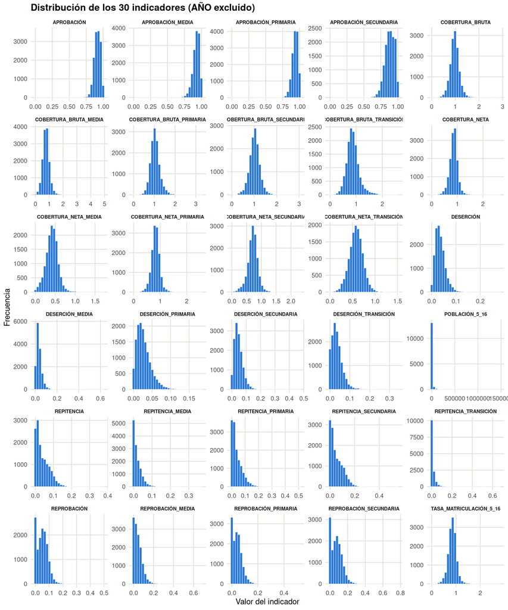

```r
datos_long <- X %>% pivot_longer(everything(), names_to = "Variable", values_to = "Valor")
p_hist <- ggplot(datos_long, aes(Valor)) +
  geom_histogram(bins = 30, fill = paleta$azul, color = "white", linewidth = 0.2) +
  facet_wrap(~ Variable, scales = "free", ncol = 5) +
  tema + theme(strip.text = element_text(size = 7, face = "bold")) +
  labs(title = "Distribución de los 30 indicadores (AÑO excluido)",
       x = "Valor del indicador", y = "Frecuencia")
print(p_hist)
```

```r
ggsave(file.path(figures_dir, "Histogramas.png"), p_hist, width = 14, height = 11, dpi = 130)
```

```r
asimetria <- function(x) { m <- mean(x); mean((x - m)^3) / sd(x)^3 }
sk <- vapply(X, asimetria, numeric(1))
```

Lectura con asimetría de Fisher (positiva = cola a la derecha):

- `POBLACIÓN_5_16`: 22,3. Pocos municipios muy grandes; la media (9.399) supera ampliamente a la mediana (3.242).
- `DESERCIÓN` (1,21), `REPROBACIÓN` (0,93) y `REPITENCIA` (1,35): **cola a la derecha**; la mayoría de registros tiene tasas bajas y unos pocos tienen tasas altas.
- `APROBACIÓN` (-2,44): **cola a la izquierda**; se concentra cerca de 1 y los valores bajos son la excepción.
- Coberturas netas y brutas: asimetría moderada (0,43 y 0,46), con una parte de los registros por encima de 1.

## 4. Valores atípicos (boxplots en escala original)

Los boxplots con Min-Max se retiraron: un boxplot ya es invariante a una transformación lineal positiva, así que normalizar no revela atípicos adicionales ni vuelve comparables las variables. Se muestra cada indicador en su escala y se cuenta cuántos registros caen fuera de los bigotes (regla 1,5 × IQR).

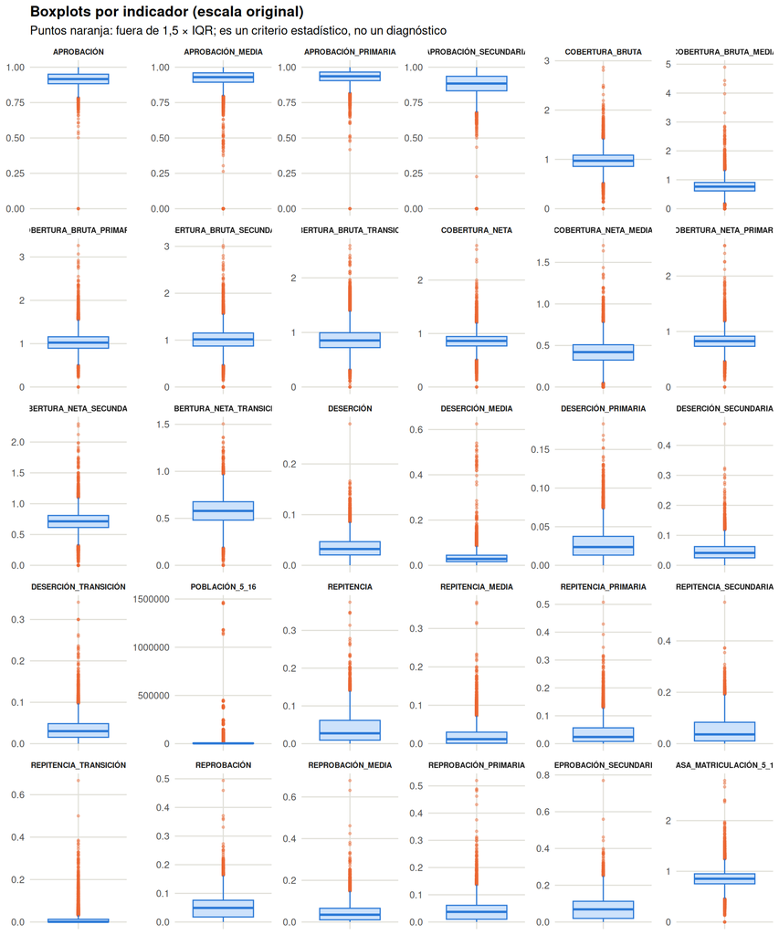

```r
atipicos <- data.frame(
  Variable = indicadores,
  Q1 = vapply(X, quantile, numeric(1), 0.25),
  Q3 = vapply(X, quantile, numeric(1), 0.75)
)
atipicos$IQR <- atipicos$Q3 - atipicos$Q1
atipicos$N_atipicos <- vapply(seq_along(indicadores), function(i) {
  v <- X[[i]]; sum(v < atipicos$Q1[i] - 1.5 * atipicos$IQR[i] | v > atipicos$Q3[i] + 1.5 * atipicos$IQR[i])
}, numeric(1))
atipicos$Pct_atipicos <- 100 * atipicos$N_atipicos / nrow(X)
rownames(atipicos) <- NULL
write.csv(atipicos, file.path(tables_dir, "Atipicos_IQR.csv"), row.names = FALSE)

p_box <- ggplot(datos_long, aes(x = "", y = Valor)) +
  geom_boxplot(fill = "#cde2fb", color = paleta$azul, outlier.color = paleta$naranja,
               outlier.alpha = 0.4, outlier.size = 0.8) +
  facet_wrap(~ Variable, scales = "free_y", ncol = 6) +
  tema + theme(strip.text = element_text(size = 7, face = "bold"),
               axis.text.x = element_blank(), axis.title.x = element_blank()) +
  labs(title = "Boxplots por indicador (escala original)",
       subtitle = "Puntos naranja: fuera de 1,5 × IQR; es un criterio estadístico, no un diagnóstico", y = NULL)
print(p_box)
```

```r
ggsave(file.path(figures_dir, "Boxplots.png"), p_box, width = 14, height = 10, dpi = 130)

kable(head(atipicos[order(-atipicos$Pct_atipicos), c("Variable", "N_atipicos", "Pct_atipicos")], 8),
      digits = 1, caption = "Indicadores con mayor porcentaje de registros fuera de los bigotes.")
```

Indicadores con mayor porcentaje de registros fuera de los bigotes.

|  | Variable | N_atipicos | Pct_atipicos |
| --- | --- | --- | --- |
| 27 | REPITENCIA_TRANSICIÓN | 1506 | 10.9 |
| 1 | POBLACIÓN_5_16 | 1332 | 9.7 |
| 6 | COBERTURA_NETA_SECUNDARIA | 608 | 4.4 |
| 3 | COBERTURA_NETA | 565 | 4.1 |
| 17 | DESERCIÓN_MEDIA | 532 | 3.9 |
| 9 | COBERTURA_BRUTA_TRANSICIÓN | 522 | 3.8 |
| 5 | COBERTURA_NETA_PRIMARIA | 504 | 3.7 |
| 2 | TASA_MATRICULACIÓN_5_16 | 490 | 3.6 |

Un punto fuera de los bigotes es un registro **estadísticamente extremo respecto a la distribución del indicador**. No prueba un error de captura ni una crisis educativa: puede ser un municipio pequeño con una tasa inestable (denominador reducido), un municipio grande o un cambio de definición. Se conservan y se marcan para revisión con información externa.

## 5. Evolución temporal: por qué `AÑO` no puede ser una variable numérica

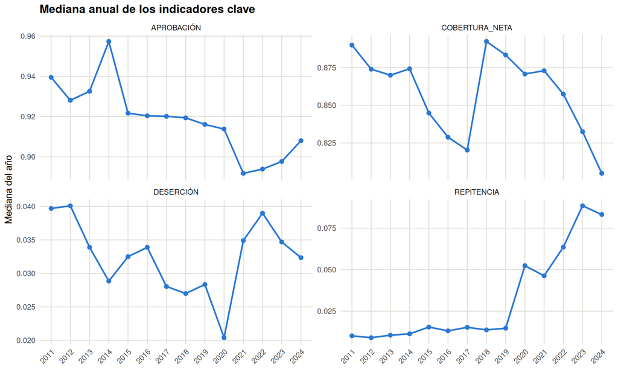

```r
clave <- c("COBERTURA_NETA", "DESERCIÓN", "APROBACIÓN", "REPITENCIA")
med_anual <- datos %>% group_by(AÑO) %>%
  summarise(across(all_of(clave), median), .groups = "drop") %>%
  pivot_longer(-AÑO, names_to = "Indicador", values_to = "Mediana")
write.csv(med_anual, file.path(tables_dir, "Mediana_anual_indicadores_clave.csv"), row.names = FALSE)

p_tiempo <- ggplot(med_anual, aes(AÑO, Mediana, group = 1)) +
  geom_line(color = paleta$azul, linewidth = 0.9) + geom_point(color = paleta$azul, size = 2) +
  facet_wrap(~ Indicador, scales = "free_y") + tema +
  theme(axis.text.x = element_text(angle = 45, hjust = 1)) +
  labs(title = "Mediana anual de los indicadores clave", x = NULL, y = "Mediana del año")
print(p_tiempo)
```

```r
ggsave(file.path(figures_dir, "Evolucion_mediana_anual.png"), p_tiempo, width = 10, height = 6, dpi = 150)

corr_anio <- data.frame(
  Indicador = indicadores,
  r_con_AÑO = vapply(X, function(v) cor(v, as.numeric(as.character(datos$AÑO))), numeric(1))
)
corr_anio <- corr_anio[order(-abs(corr_anio$r_con_AÑO)), ]
write.csv(corr_anio, file.path(tables_dir, "Correlacion_con_anio.csv"), row.names = FALSE)
kable(head(corr_anio, 6), digits = 3, row.names = FALSE,
      caption = "Correlación de cada indicador con el año calendario (solo diagnóstico).")
```

Correlación de cada indicador con el año calendario (solo diagnóstico).

| Indicador | r_con_AÑO |
| --- | --- |
| REPITENCIA | 0.659 |
| REPITENCIA_SECUNDARIA | 0.634 |
| REPITENCIA_PRIMARIA | 0.601 |
| REPITENCIA_MEDIA | 0.447 |
| REPROBACIÓN | 0.331 |
| REPROBACIÓN_SECUNDARIA | 0.325 |

```r
rep_med <- med_anual$Mediana[med_anual$Indicador == "REPITENCIA"]
names(rep_med) <- med_anual$AÑO[med_anual$Indicador == "REPITENCIA"]
```

La repitencia tiene una correlación de 0,66 con el año calendario y su mediana pasa de 0,015 en 2019 a 0,052 en 2020 y 0,083 en 2024. Si `AÑO` entra como variable numérica en la matriz de correlaciones, parte de lo que se lee como «relación entre indicadores» es en realidad **tendencia temporal compartida**. La coincidencia del salto con 2020 es una pista, no una explicación: requiere confirmarse con la fuente administrativa. Por eso `AÑO` se trata como categoría y las correlaciones se verifican también **dentro de cada año** (sección 6).

## 6. Relaciones bivariadas y sensibilidad

```r
pares <- list(
  c("COBERTURA_NETA", "COBERTURA_BRUTA"),
  c("APROBACIÓN_SECUNDARIA", "REPROBACIÓN_SECUNDARIA"),
  c("DESERCIÓN", "DESERCIÓN_SECUNDARIA"),
  c("REPITENCIA", "REPITENCIA_PRIMARIA"),
  c("APROBACIÓN", "REPROBACIÓN"),
  c("DESERCIÓN", "REPITENCIA"),
  c("COBERTURA_NETA", "DESERCIÓN"),
  c("POBLACIÓN_5_16", "COBERTURA_NETA")
)
X_anio <- centrar_por_grupo(X, datos$AÑO)         # sin diferencias entre años
X_mun <- centrar_por_grupo(X, datos$ID_MUNICIPIO) # solo variación dentro del municipio
desde_2016 <- datos$AÑO >= "2016"

sens <- do.call(rbind, lapply(pares, function(p) {
  cl <- correlacion_cluster(datos[[p[1]]], datos[[p[2]]], datos$ID_MUNICIPIO, B = 1000)
  data.frame(
    Par = paste(p, collapse = " ~ "),
    r_Pearson = unname(cl["r"]), IC95_inf = unname(cl["lo"]), IC95_sup = unname(cl["hi"]),
    r_2016_2024 = cor(datos[[p[1]]][desde_2016], datos[[p[2]]][desde_2016]),
    r_dentro_de_año = cor(X_anio[[p[1]]], X_anio[[p[2]]]),
    r_dentro_de_municipio = cor(X_mun[[p[1]]], X_mun[[p[2]]]),
    r_Spearman = cor(datos[[p[1]]], datos[[p[2]]], method = "spearman")
  )
}))
rownames(sens) <- NULL
write.csv(sens, file.path(tables_dir, "Correlaciones_clave_sensibilidad.csv"), row.names = FALSE)
kable(sens, digits = 3,
      caption = "Correlaciones clave. IC95: bootstrap por municipio (1.000 réplicas). Las demás columnas son verificaciones de sensibilidad.")
```

Correlaciones clave. IC95: bootstrap por municipio (1.000 réplicas). Las demás columnas son verificaciones de sensibilidad.

| Par | r_Pearson | IC95_inf | IC95_sup | r_2016_2024 | r_dentro_de_año | r_dentro_de_municipio | r_Spearman |
| --- | --- | --- | --- | --- | --- | --- | --- |
| COBERTURA_NETA ~ COBERTURA_BRUTA | 0.922 | 0.912 | 0.931 | 0.957 | 0.923 | 0.864 | 0.913 |
| APROBACIÓN_SECUNDARIA ~ REPROBACIÓN_SECUNDARIA | -0.806 | -0.880 | -0.730 | -0.774 | -0.791 | -0.867 | -0.898 |
| DESERCIÓN ~ DESERCIÓN_SECUNDARIA | 0.893 | 0.883 | 0.902 | 0.895 | 0.891 | 0.866 | 0.910 |
| REPITENCIA ~ REPITENCIA_PRIMARIA | 0.930 | 0.925 | 0.935 | 0.920 | 0.867 | 0.941 | 0.946 |
| APROBACIÓN ~ REPROBACIÓN | -0.846 | -0.905 | -0.753 | -0.830 | -0.836 | -0.899 | -0.897 |
| DESERCIÓN ~ REPITENCIA | 0.087 | 0.061 | 0.110 | 0.162 | 0.122 | 0.070 | 0.069 |
| COBERTURA_NETA ~ DESERCIÓN | -0.005 | -0.043 | 0.033 | -0.006 | -0.005 | -0.004 | 0.022 |
| POBLACIÓN_5_16 ~ COBERTURA_NETA | 0.046 | 0.027 | 0.109 | 0.054 | 0.046 | -0.118 | 0.172 |

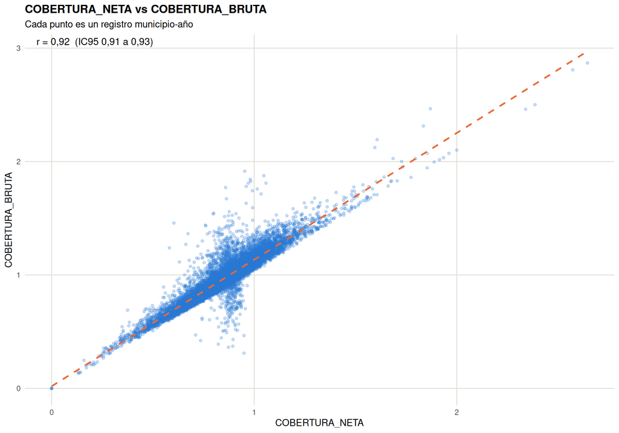

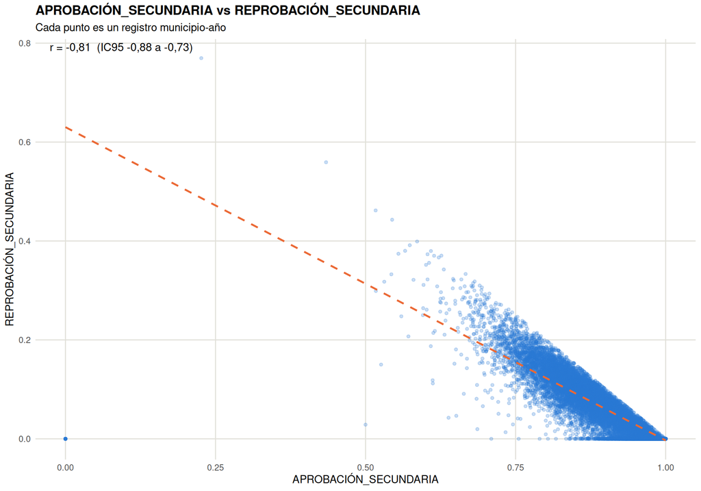

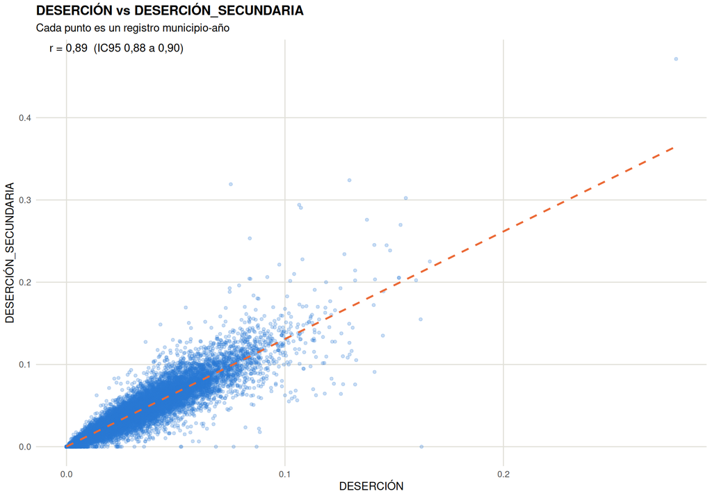

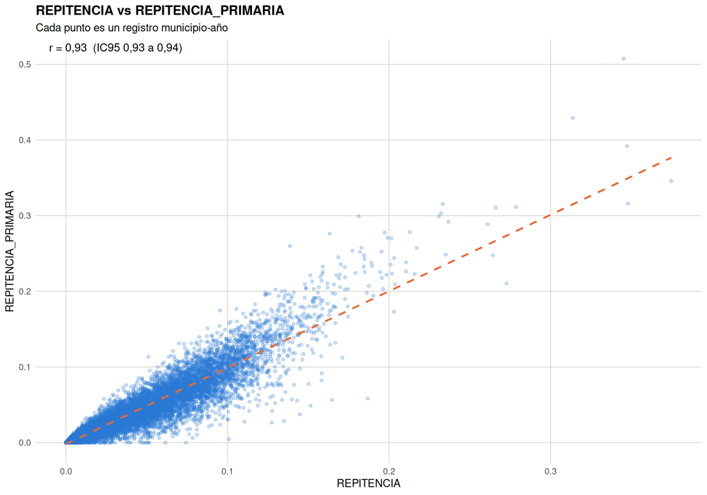

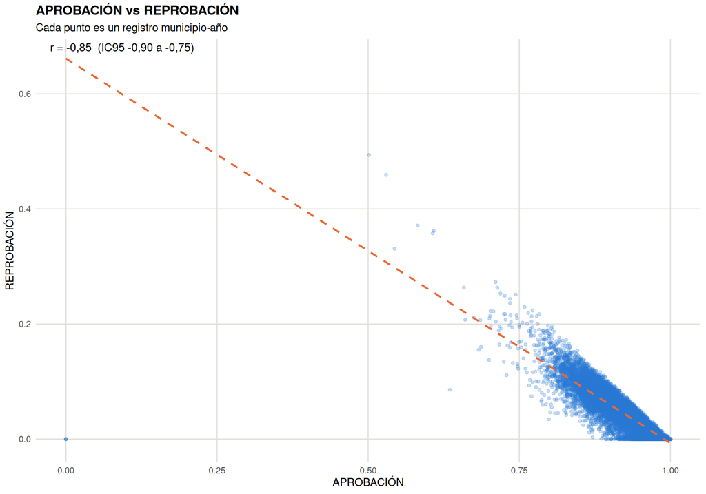

```r
for (i in 1:5) {
  v1 <- pares[[i]][1]; v2 <- pares[[i]][2]
  p <- ggplot(datos, aes(x = .data[[v1]], y = .data[[v2]])) +
    geom_point(alpha = 0.25, color = paleta$azul, size = 1.2) +
    geom_smooth(method = "lm", color = paleta$naranja, se = FALSE, linetype = "dashed", linewidth = 0.9) +
    annotate("text", x = -Inf, y = Inf, hjust = -0.1, vjust = 1.5, size = 4,
             label = paste0("r = ", fnum(sens$r_Pearson[i], 2), "  (IC95 ", fnum(sens$IC95_inf[i], 2), " a ", fnum(sens$IC95_sup[i], 2), ")")) +
    tema + labs(title = paste(v1, "vs", v2), x = v1, y = v2,
                subtitle = "Cada punto es un registro municipio-año")
  print(p)
  ggsave(file.path(figures_dir, paste0("dispersion_", safe_file_name(v1), "_vs_", safe_file_name(v2), ".png")),
         p, width = 6.5, height = 4.5, dpi = 150)
}
```

Lectura (siempre como **asociación**, no causalidad):

- Pares del mismo fenómeno medido en distinto nivel (`COBERTURA_NETA`~`COBERTURA_BRUTA`, `DESERCIÓN`~`DESERCIÓN_SECUNDARIA`, `REPITENCIA`~`REPITENCIA_PRIMARIA`) tienen coeficientes entre 0,89 y 0,93, estables en las cuatro especificaciones. Es redundancia de medición, no un hallazgo sustantivo.
- `APROBACIÓN`~`REPROBACIÓN`: -0,846. Es fuerte y negativa pero **no «perfecta»**: la deserción absorbe parte de la diferencia (aprobación + reprobación + deserción ≈ 1).
- `DESERCIÓN`~`REPITENCIA`: 0,09 y `COBERTURA_NETA`~`DESERCIÓN`: -0,01 (IC95 que incluye 0). La cobertura agregada no está asociada linealmente con la deserción.
- `POBLACIÓN_5_16`~`COBERTURA_NETA`: la correlación cambia según la especificación (de 0,05 dentro de año a -0,12 dentro de municipio) y Pearson está dominado por pocos municipios muy grandes; la lectura segura es «sin relación lineal clara».

## 7. Matriz de correlación (30 indicadores, sin AÑO)

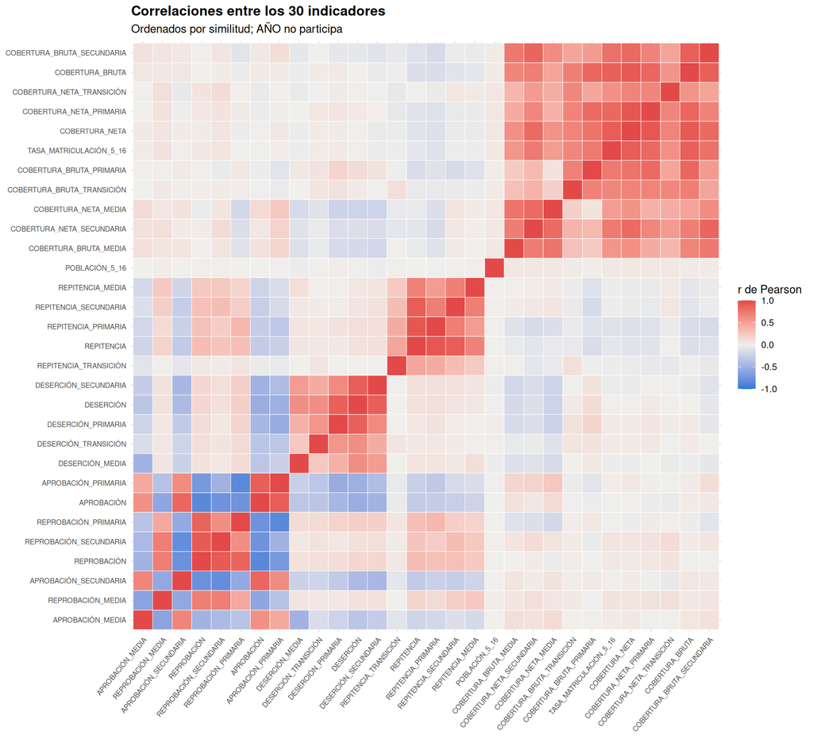

```r
matriz_corr <- cor(X)
write.csv(matriz_corr, file.path(tables_dir, "Matriz_Correlacion.csv"))

orden <- hclust(as.dist(1 - abs(matriz_corr)))$order
niveles <- colnames(matriz_corr)[orden]
cl <- as.data.frame(as.table(matriz_corr))
names(cl) <- c("V1", "V2", "r")
cl$V1 <- factor(cl$V1, levels = niveles); cl$V2 <- factor(cl$V2, levels = niveles)

p_corr <- ggplot(cl, aes(V1, V2, fill = r)) +
  geom_tile(color = "white", linewidth = 0.2) +
  scale_fill_gradient2(low = paleta$azul, mid = "#f0efec", high = "#e34948",
                       midpoint = 0, limits = c(-1, 1), name = "r de Pearson") +
  tema + theme(axis.text.x = element_text(angle = 50, hjust = 1, size = 7),
               axis.text.y = element_text(size = 7), axis.title = element_blank(),
               panel.grid = element_blank()) +
  labs(title = "Correlaciones entre los 30 indicadores", subtitle = "Ordenados por similitud; AÑO no participa")
print(p_corr)
```

```r
ggsave(file.path(figures_dir, "Heatmap_Correlacion.png"), p_corr, width = 11, height = 10, dpi = 140)

tri <- which(upper.tri(matriz_corr), arr.ind = TRUE)
pares_corr <- data.frame(Var1 = rownames(matriz_corr)[tri[, 1]], Var2 = colnames(matriz_corr)[tri[, 2]],
                         r = matriz_corr[tri])
pares_red <- pares_corr[abs(pares_corr$r) >= 0.9, ]
pares_red <- pares_red[order(-abs(pares_red$r)), ]
write.csv(pares_red, file.path(tables_dir, "Pares_redundantes.csv"), row.names = FALSE)
kable(pares_red, digits = 3, row.names = FALSE, caption = "Pares con |r| >= 0,90 (redundancia estadística).")
```

Pares con |r| >= 0,90 (redundancia estadística).

| Var1 | Var2 | r |
| --- | --- | --- |
| COBERTURA_NETA | COBERTURA_NETA_PRIMARIA | 0.931 |
| REPITENCIA | REPITENCIA_PRIMARIA | 0.930 |
| COBERTURA_NETA | COBERTURA_BRUTA | 0.922 |
| REPROBACIÓN | REPROBACIÓN_SECUNDARIA | 0.915 |
| REPITENCIA | REPITENCIA_SECUNDARIA | 0.901 |

De las 435 parejas, 5 tienen |r| ≥ 0,90 y 41 tienen |r| ≥ 0,70. Los bloques visibles agrupan indicadores que miden lo mismo por nivel educativo (cobertura neta/bruta, deserción por nivel, aprobación y reprobación). La correlación alta indica **redundancia**, no causalidad. Antes de modelar se deben elegir pocos representantes por bloque (como hace el taller de PCA). No se presentan valores p: con 13.802 filas y 435 pares casi todo sería «significativo» y las filas no son independientes.

## 8. Conclusiones corregidas

1. **Unidad de análisis.** Son registros municipio-año de 1.123 municipios; el panel es desbalanceado y sub-representa 2011-2015. Los resultados describen el conjunto completo y no se pueden leer como una foto de un solo año.
2. **Categóricas.** Las 3 categóricas se analizaron aparte: el municipio explica una mediana de 43 % de la varianza de un indicador, el departamento 14 % y el año 6 %; son persistencia del mismo territorio, no un patrón nuevo.
3. **Tiempo.** `AÑO` es una categoría. Su inclusión como número mezclaba tendencia con relación entre indicadores; la repitencia, en particular, cambia de nivel desde 2020.
4. **Distribuciones.** Población, deserción, reprobación y repitencia tienen cola derecha; la aprobación tiene cola izquierda. (La versión anterior describía estos sesgos al revés.)
5. **Atípicos.** Se cuantifican con la regla IQR y se conservan. No se interpretan como crisis sin validación externa; las tasas de municipios pequeños pueden ser inestables.
6. **Asociaciones.** Las correlaciones más altas son redundancias entre niveles del mismo indicador. Aprobación y reprobación están fuertemente asociadas (r = -0,85), no perfectamente; cobertura neta y deserción no muestran asociación lineal.
7. **Inferencia.** Se reportan magnitudes con intervalos por municipio y su robustez (2016-2024, dentro de año, dentro de municipio, Spearman); no se usan valores p sin ajuste.
8. **Pendiente de validación.** Definición y denominadores de las tasas > 100 %, causa del salto de 2020, qué municipios faltan en 2011-2015 y sensibilidad con ponderación por población.